# Amazon Pick Me

## Project Description/Outline

Analyzing best location selection based on labor force demographics, transportation infrastructure, living cost, and amenities near the site for the second Amazon headquarter on 8 of the 20 city finalists.

## Research Questions to Answer

From the RFP: In choosing the location for HQ2, Amazon has a preference for:

- Metropolitan areas with more than one million people
- A stable and business-friendly environment
- Urban or suburban locations with the potential to attract and retain strong technical talent
- Communities that think big and creatively when considering locations and real estate options

From the RFP: In choosing the location for HQ2, Amazon has a preference for:

- Metropolitan areas with more than one million people
- A stable and business-friendly environment
- **Urban or suburban locations with the potential to attract and retain strong technical talent**
- Communities that think big and creatively when considering locations and real estate options

Team amazonians:

- Indu
- Helen
- Niyanti
- Guirlyn

### Data Sets to be Used

**1st Category: Demographics** For Corporation

- Team Member: Indu
- API: Census data

**2nd Category: Transportation infrastructure** For Employees

- Team Member: Helen
- API: Google search

**3rd Category: Living Cost** For Employees

- Team Member: Guirlyn
- API: Census data

**4th Category: Large enterprises** For Corporations

- Team Member: Niyati
- Google search

Criteras Demographics

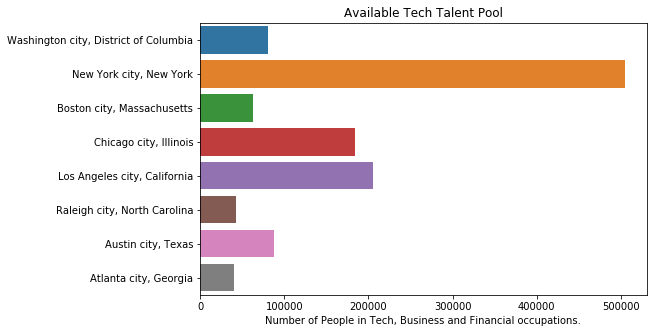

```python
# Plotting Talent pool
plt.figure(figsize=(8,5))
sns.barplot(y='NAME',x='Emp_Tech',data=laborForceDF)
plt.xlabel("Number of People in Tech, Business and Financial occupations.")
plt.ylabel("")
plt.title("Available Tech Talent Pool")
plt.show()
```

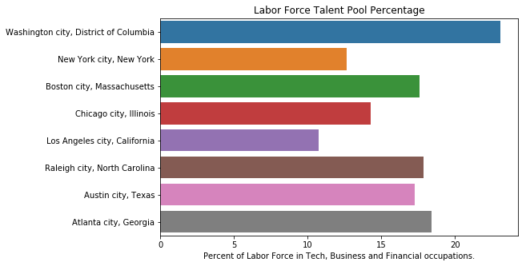

```python
plt.figure(figsize=(8,5))

sns.barplot(y='NAME',x='Emp_Tech_Per',data=laborForceDF)
plt.xlabel("Percent of Labor Force in Tech, Business and Financial occupations.")
plt.ylabel("")
plt.title("Labor Force Talent Pool Percentage")
plt.show()
```

Criteria Living Cost

```python
housing_df=pd.read_csv("housing.csv")
housing_df_temp_own = housing_df.copy()
housing_df_temp_rent = housing_df.copy()
housing_df_temp_own['RentOwn'] = 'own'
housing_df_temp_own['Afford'] = housing_df_temp_own['home owner afford']
housing_df_temp_rent['RentOwn'] = 'rent'
housing_df_temp_rent['Afford'] = housing_df_temp_own['rent afford']
frames= [housing_df_temp_own, housing_df_temp_rent]
housing_df_rentOwn = pd.concat(frames, ignore_index= 'True')
```

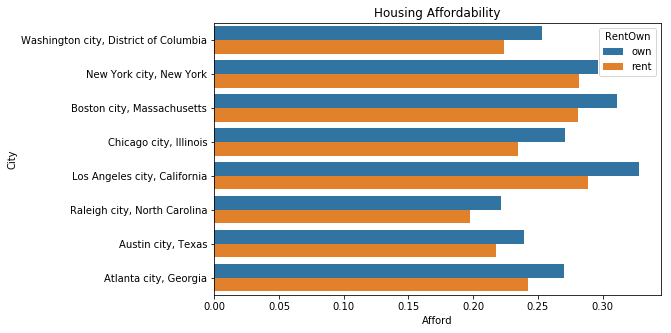

```python
#By City
plt.figure(figsize=(8,5))
sns.barplot(x="Afford", y="City", hue="RentOwn", data=housing_df_rentOwn)
plt.title("Housing Affordability")

plt.show()
```

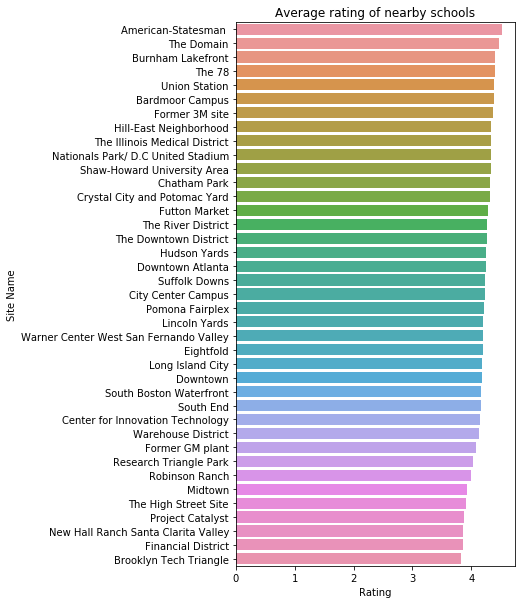

```python
plt.figure(figsize=(5,10))
sns.barplot(x='Rating',y='Site Name',data=avg_rating)
plt.title("Average rating of nearby schools")
plt.show()
```

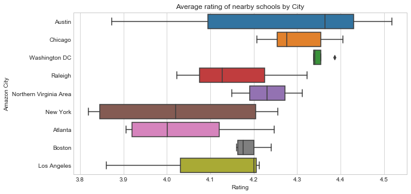

```python
# Nearby schools average ratings
sns.boxplot(x='Rating',y='Amazon City',data=cities)
plt.title("Average rating of nearby schools by City")
plt.savefig("ratingsschoolscity.png")
plt.show()
```

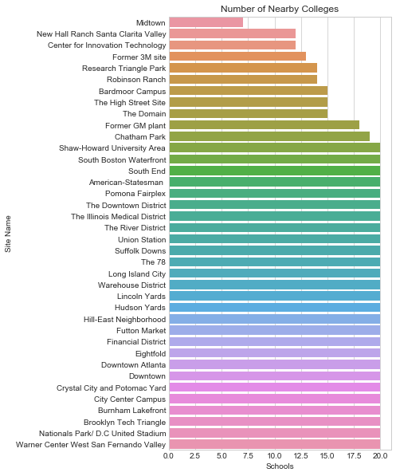

```python
# Nearby Colleges average ratings
plt.figure(figsize=(5,10))
sns.barplot(x='Schools',y='Site Name',data=nc)
plt.title("Number of Nearby Colleges")
plt.savefig("nerbycolleges.png")
plt.show()
```

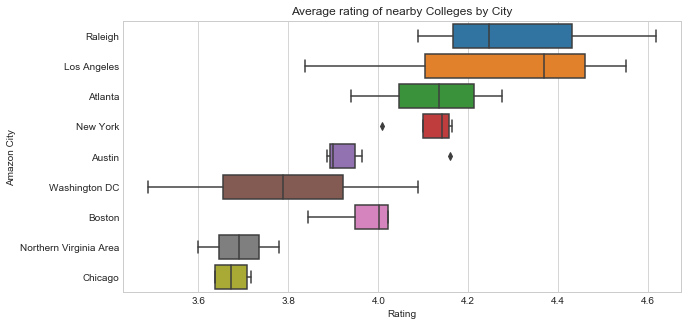

```python
# Nearby Colleges average ratings
sns.boxplot(x='Rating',y='Amazon City',data=cities)
plt.title("Average rating of nearby Colleges by City")
plt.show()
```

Thank you